# Prosper Loan Interest Rate Factors

## by Roy Amante A. Salvador

## Investigation Overview

Prosper is a peer to peer lending platform for US residents. In this investigation, we are interested on finding out the factors in predicting a loan's interest rate at Prosper. Interest rate is a metric for determining how hard it is to borrow money.

## Dataset Overview

The data consists of 113,387 Prosper Loan Listings with 81 variables such as amount of loan, interest rate, status of loan, borrower information among many more.

## Distribution of Prosper Loan Interest Rates

- Most common interest rates in Prosper loans fall around 15% and 30%. It's rare to have interest rates below 5% or above 35%.

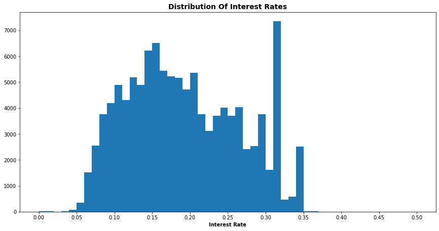

```python
# plot histogram of interest rate
binsize = 0.01
min_ir = df['BorrowerRate'].min()
max_ir = df['BorrowerRate'].max()
bins = np.arange(0, max_ir+binsize, binsize)
plt.figure(figsize=[14.70, 7.27])
plt.hist(data = df, x = 'BorrowerRate', bins=bins)
plt.xticks(np.arange(min_ir, max_ir+binsize, 0.05))
plt.xlabel('Interest Rate'.title(),
               fontsize = 10, weight = "bold" )
plt.title('Distribution of Interest Rates'.title(),
               fontsize = 14, weight = "bold" )
plt.show()
```

## Motivation: Investors and Loan Status

- We like to have good interest rates with our loans to attract more investors. Interest Rate is seen to have a moderate negative correlation with the number of investors.
- To increase our chances of successful repayment, we desire lower interest rates. Delinquent loans (Defaulted, Chargedoff and with past due) have interest rates typically more than 20%. Lower interest rates are seen for loans with healthy status.

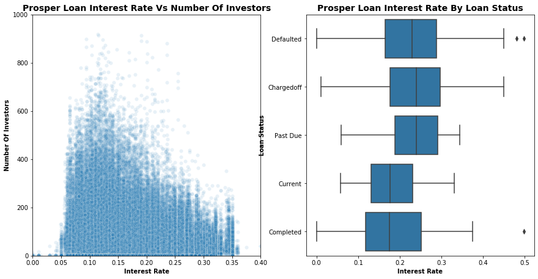

```python
fig, ax = plt.subplots(ncols = 2, nrows = 1, figsize=[14.70, 7.27])

# Plot Interest Rate vs Number of Investors
sb.scatterplot(data=df, x = 'BorrowerRate', y='Investors', alpha=1/10, ax=ax[0])
ax[0].set_ylabel('Number of Investors'.title(),
               fontsize = 10, weight = "bold" )
ax[0].set_xlabel('Interest Rate'.title(),
               fontsize = 10, weight = "bold" )
ax[0].set_title('Prosper Loan Interest Rate vs Number of Investors'.title(),
               fontsize = 14, weight = "bold" )
ax[0].set_xlim(0,0.4)
ax[0].set_ylim(0,1000)

# Plot Interest Rate by Loan Status
sb.boxplot(data=df, y = 'LoanStatusSimplified', x = 'BorrowerRate', color = default_color, ax=ax[1])
ax[1].set_title('Prosper Loan Interest Rate by Loan Status'.title(),
               fontsize = 14, weight = "bold" )
ax[1].set_ylabel('Loan Status'.title(),
               fontsize = 10, weight = "bold" )
ax[1].set_xlabel('Interest Rate'.title(),
               fontsize = 10, weight = "bold" )
plt.show();
```

## Factor: Loan Amount and Term

- Bigger loan amounts tend to have lower interest rates.
- Loan terms with higher number of months tend to have higher interest rates.

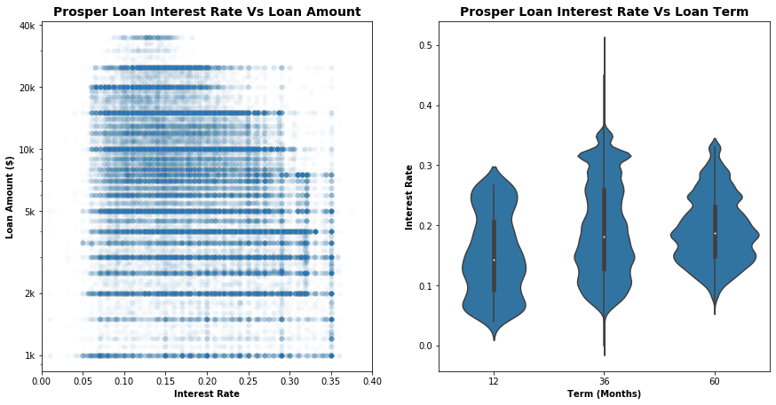

```python
# plot matrix: sample 500 samples so that plots are clearer and
# they render faster
samples = np.random.choice(df.shape[0], 1000, replace = False)
df_samp = df.loc[samples,:]

fig, ax = plt.subplots(ncols = 2, nrows = 1, figsize=[14.70, 7.27]);

# Plot Interest Rate vs Loan Amount
sb.scatterplot(data=df, x = 'BorrowerRate', y='LoanOriginalAmount', alpha=1/50, ax=ax[0])
ax[0].set_ylabel('Loan Amount ($)'.title(),
               fontsize = 10, weight = "bold" )
ax[0].set_xlabel('Interest Rate'.title(),
               fontsize = 10, weight = "bold" )
ax[0].set_title('Prosper Loan Interest Rate vs Loan Amount'.title(),
               fontsize = 14, weight = "bold" );
ax[0].set_xlim(0, 0.4)
ax[0].set_yscale('log')
ax[0].set_yticks(np.array([1e3, 2e3, 5e3, 1e4, 2e4, 4e4]))
ax[0].set_yticklabels(['1k', '2k', '5k', '10k', '20k', '40k'])

# Plot Interest Rate vs Loan Term
default_color = sb.color_palette()[0]
sb.violinplot(data=df, y = 'BorrowerRate', x = 'Term', color = default_color, ax=ax[1])
ax[1].set_title('Prosper Loan Interest Rate vs Loan Term'.title(),
               fontsize = 14, weight = "bold" )
ax[1].set_xlabel('Term (months)'.title(),
               fontsize = 10, weight = "bold" )
ax[1].set_ylabel('Interest Rate'.title(),
               fontsize = 10, weight = "bold" )

fig.show();
```

## Factor: Loan Risk Rating

- Loans with high risk ratings tend to have higher interest rates. This remained consistent even after the risk rating system changed in 2009.

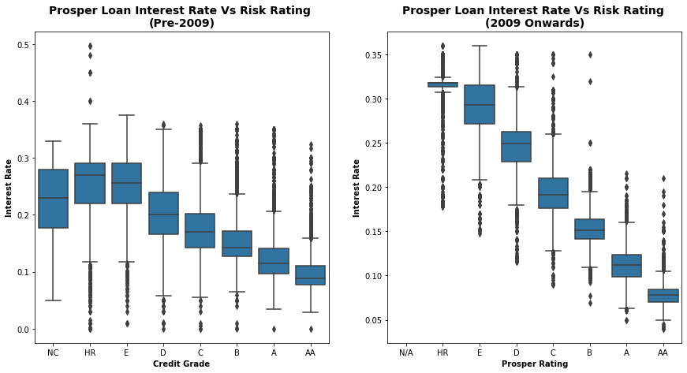

```python
fig, ax = plt.subplots(ncols = 2, nrows = 1, figsize=[14.70, 7.27]);

# Plot Interest Rate vs Loan Amount
default_color = sb.color_palette()[0]
sb.boxplot(data=df, y = 'BorrowerRate', x = 'CreditGrade', color = default_color, ax=ax[0])
ax[0].set_title('Prosper Loan Interest Rate vs Risk Rating \n(pre-2009)'.title(),
               fontsize = 14, weight = "bold" );
ax[0].set_xlabel('Credit Grade'.title(),
               fontsize = 10, weight = "bold" );
ax[0].set_ylabel('Interest Rate'.title(),
               fontsize = 10, weight = "bold" );


# Plot Interest Rate vs Loan Term
default_color = sb.color_palette()[0]
sb.boxplot(data=df, y = 'BorrowerRate', x = 'ProsperRating (Alpha)', color = default_color, ax=ax[1])
ax[1].set_title('Prosper Loan Interest Rate vs Risk Rating \n(2009 onwards)'.title(),
               fontsize = 14, weight = "bold" );
ax[1].set_xlabel('Prosper Rating'.title(),
               fontsize = 10, weight = "bold" );
ax[1].set_ylabel('Interest Rate'.title(),
               fontsize = 10, weight = "bold" );

fig.show();
```

## Factor: Loan Category and Borrower's Income Range

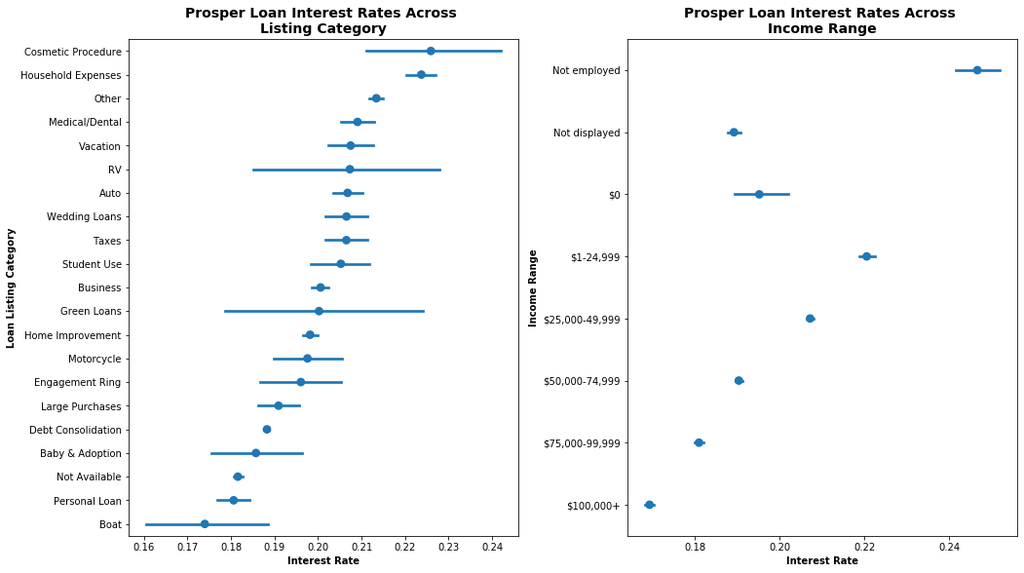

```python
fig, ax = plt.subplots(ncols = 2, nrows = 1, figsize=[14.70, 8.27]);

# Plot Interest Rate by Listing Category
sb.pointplot(data = df, y = 'ListingCategoryDesc', x='BorrowerRate', linestyles = '', ax=ax[0])
ax[0].set_ylabel('Loan Listing Category'.title(),
               fontsize = 10, weight = "bold" );
ax[0].set_xlabel('Interest Rate'.title(),
               fontsize = 10, weight = "bold" );
ax[0].set_title('Prosper Loan Interest Rates Across \nListing Category'.title(),
               fontsize = 14, weight = "bold" );

# Plot Interest Rate by Income Range
sb.pointplot(data = df, y = 'IncomeRange', x='BorrowerRate', linestyles = '', ax=ax[1])
ax[1].set_ylabel('Income Range'.title(),
               fontsize = 10, weight = "bold" );
ax[1].set_xlabel('Interest Rate'.title(),
               fontsize = 10, weight = "bold" );
ax[1].set_title('Prosper Loan Interest Rates Across \nIncome Range'.title(),
               fontsize = 14, weight = "bold" );
fig.tight_layout()
```

## Factor: Borrower's Credit Score and Group Membership

- Lower interest rates are associated with loan listings whose borrowers have better [Credit Score](https://www.experian.com/blogs/ask-experian/credit-education/score-basics/what-is-a-good-credit-score/)
- Interaction with Credit Score reveals members of a group in Prosper get lower interest rates than those with no membership
- Historically, Group membership however has always been slower in originating the loan. This might be caused by some additional process the loan listing has to go through such as group leader approval.

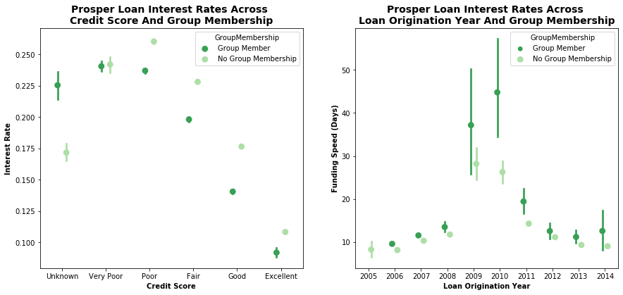

```python
df['FundingSpeedDays']  = ( pd.to_datetime(df['LoanOriginationDate']) - pd.to_datetime(df['ListingCreationDate']) ) \
    / pd.to_timedelta(1, unit='D')

fig, ax = plt.subplots(ncols = 2, nrows = 1, figsize=[14.70, 6.27]);

# Plot Interest Rate by Credit Score and Credit Score
sb.pointplot(data = df, x = 'CreditScore', y='BorrowerRate',
             hue = 'GroupMembership', linestyles = '',
             palette = 'Greens_r', dodge=0.2, ax=ax[0])
ax[0].set_xlabel('Credit Score'.title(),
               fontsize = 10, weight = "bold")
ax[0].set_ylabel('Interest Rate'.title(),
               fontsize = 10, weight = "bold")
ax[0].set_title('Prosper Loan Interest Rates Across \nCredit Score and Group Membership'.title(),
               fontsize = 14, weight = "bold")

# Plot Funding Speed by Loan Origination Year and Group Membership
sb.pointplot(data = df, x = 'LoanOriginationYear', y='FundingSpeedDays',
             hue = 'GroupMembership', linestyles = '',
             palette = 'Greens_r', dodge=0.2, ax=ax[1])
ax[1].set_xlabel('Loan Origination Year'.title(),
               fontsize = 10, weight = "bold")
ax[1].set_ylabel('Funding Speed (days)'.title(),
               fontsize = 10, weight = "bold")
ax[1].set_title('Prosper Loan Interest Rates Across \nLoan Origination Year and Group Membership'.title(),
               fontsize = 14, weight = "bold")
plt.show()
```

## Factor: Timing

- From 2007 to 2011, interest rates are increasing. 2011 until 2014, it became decreasing . This might be caused by economic trends (e.g. 2008 Global Financial Crisis) so timing also matters.

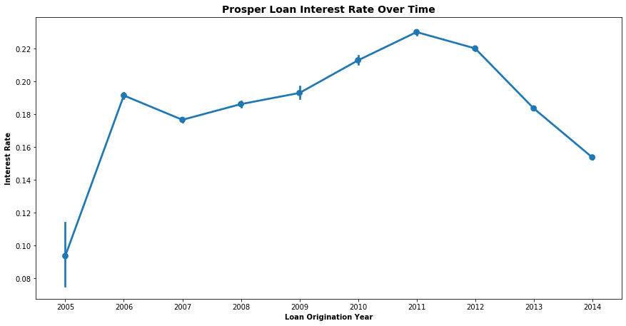

```python
plt.figure(figsize=[14.70, 7.27])
sb.pointplot(data = df, y = 'BorrowerRate', x='LoanOriginationYear', linestyles = '-')
plt.ylabel('Interest Rate'.title(),
               fontsize = 10, weight = "bold")
plt.xlabel('Loan Origination Year'.title(),
               fontsize = 10, weight = "bold")
plt.title('Prosper Loan Interest Rate Over Time'.title(),
               fontsize = 14, weight = "bold")
plt.show()
```